# Homework 4: Q-learning

Author: Hao Ren Date: Feb 11, 2026

## Part 1: Tabular Q-Learning

### Experimental Setup

We implement one-step tabular Q-learning on the Blackjack-v1 environment. As a tabular Q-learning algorithm, the Q-table is just a dictionary mapping (state, action) pairs to estimated values.

**Hyperparameters (shared across configs):** - Learning rate *α* = 0.01 - Discount factor *γ* = 0.95 - Training episodes: 100,000 - Evaluation window (rolling average): 500 episodes

**Exploration strategies tested:**

We compare two families of exploration strategies:

1. *ε*-greedy with various fixed and decaying epsilon values:
   - Fixed: *ε* = 0.01, 0.1, 0.5, 0.9, 1.0
   - Decaying: *ε* = 0.1 → 0.01, *ε* = 0.5 → 0.05, *ε* = 1.0 → 0.1
2. **Boltzmann (softmax) exploration** with decaying temperature:
   - *τ* = 10.0 → 0.1
   - *τ* = 1.0 → 0.01
   - *τ* = 0.5 → 0.01

Epsilon and temperature are linearly decayed over the first half of training. A **random baseline** (uniform random action selection) is also evaluated for comparison.

### Results

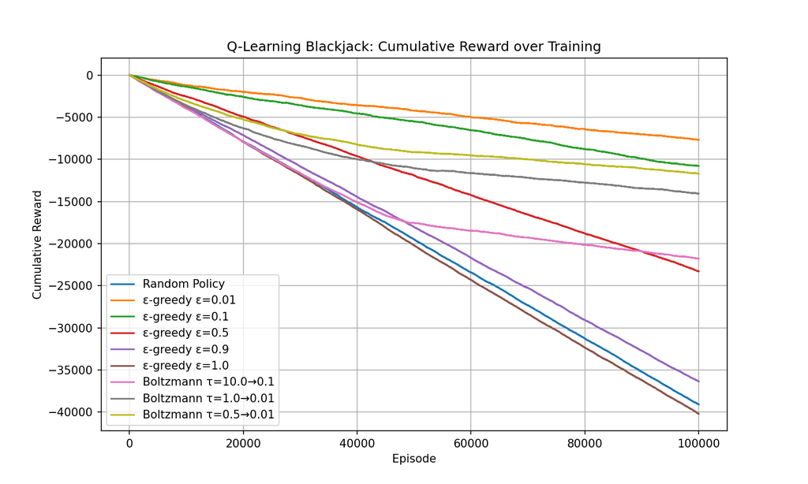

Blackjack cumulative reward comparison

*ε*-greedy with fixed epsilon:

Config

Detail Plot

*ε* = 0.01

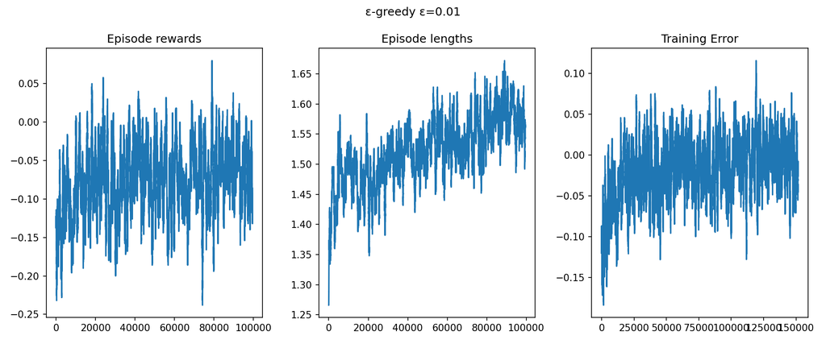

*ε* = 0.1

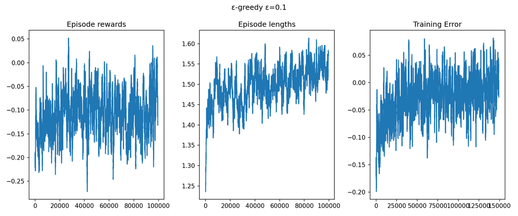

*ε* = 0.5

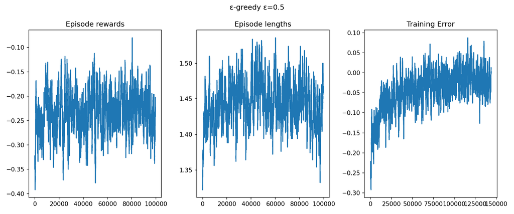

*ε* = 0.9

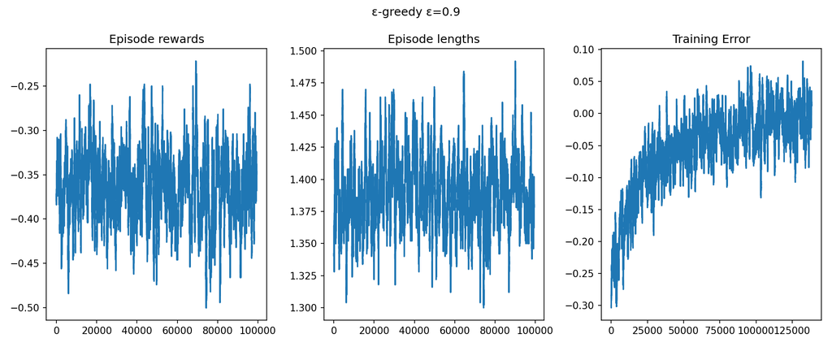

*ε* = 1.0

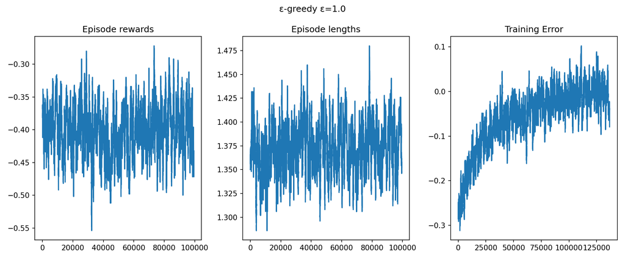

*ε*-greedy with decaying epsilon:

Config

Detail Plot

*ε* = 0.1 → 0.01

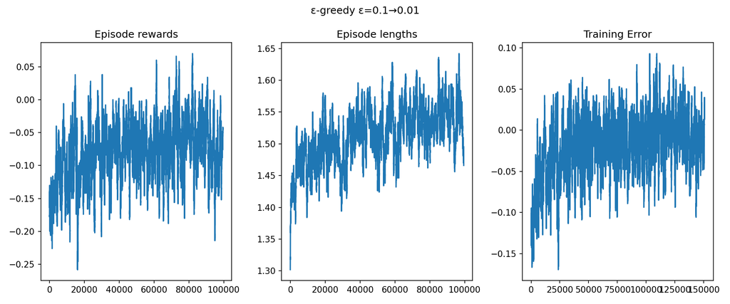

*ε* = 0.5 → 0.05

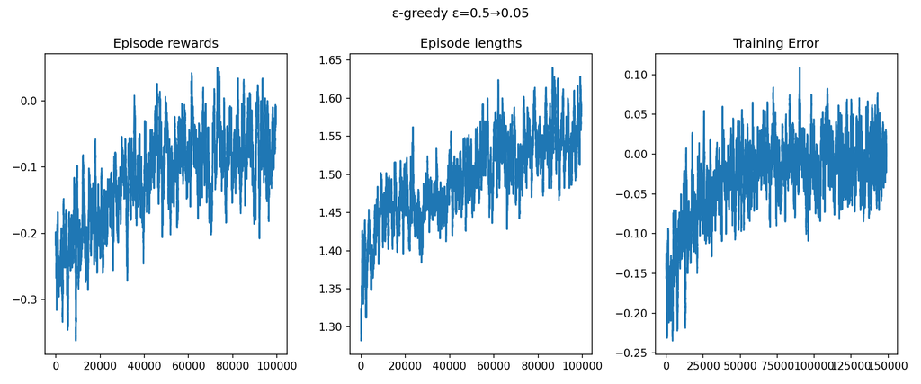

*ε* = 1.0 → 0.1

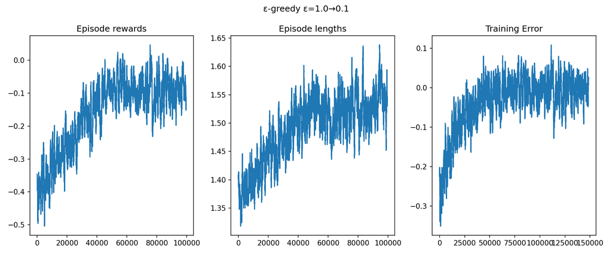

**Boltzmann exploration:**

Config

Detail Plot

*τ* = 10.0 → 0.1

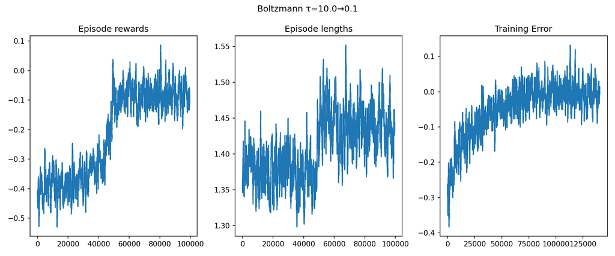

*τ* = 1.0 → 0.01

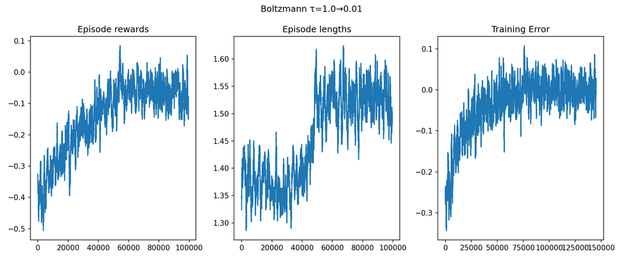

*τ* = 0.5 → 0.01

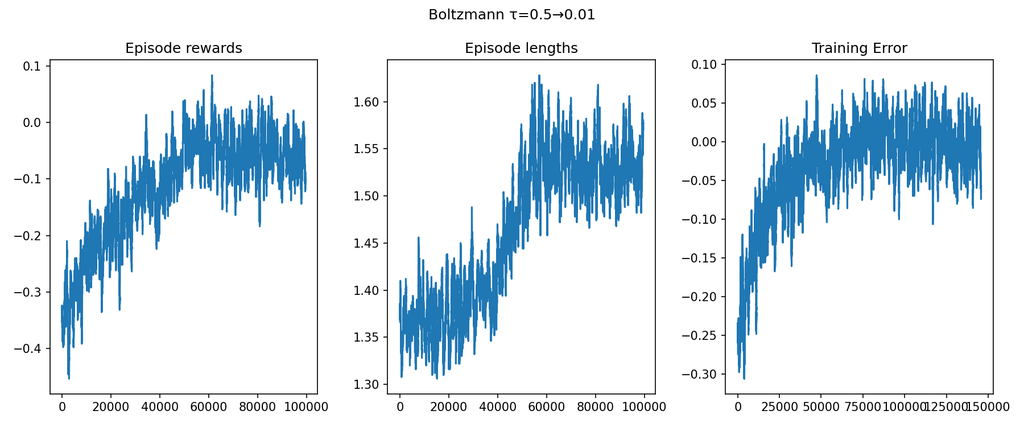

Each detail plot shows three panels: the rolling-average episode reward, episode length, and TD training error over the course of training.

## Part 2: DQN for lunar lander

### Experimental Setup

We implement a DQN agent using a 3-layer MLP architecture.

**Network architecture:** A 3-layer MLP ($8 → 128 → 128 → 4$) with ReLU activations.

**Hyperparameters:**

We refer to the PyTorch DQN tutorial for recommended hyperparameters: - Batch size: 128 - Discount factor *γ* = 0.99 - Epsilon: $0.9 → 0.01$ (exponential decay, *τ* = 2500 steps) - Learning rate: 3 × 10<sup>−4</sup> (AdamW with AMSGrad) - Target network: soft update with *τ* = 0.005 every step - Replay memory: 100,000 transitions - Loss: Smooth L1 (Huber) loss - Gradient clipping: max value 100 - Training episodes: 600

**Baseline:** A random agent taking uniformly random actions over 100 episodes, providing average duration and reward reference lines on the training charts.

### Results

**MLP DQN training curves:**

The chart “Episode Duration Over Training” shows that the agent is able to land the lunar module faster over time, and the “Total Reward Per Episode” chart shows a increase in reward, until reaching a plateau around reward = 250, which is good enough for this experiment. I played this a few times and never get a positive reward :(. The best score I got is around -16.

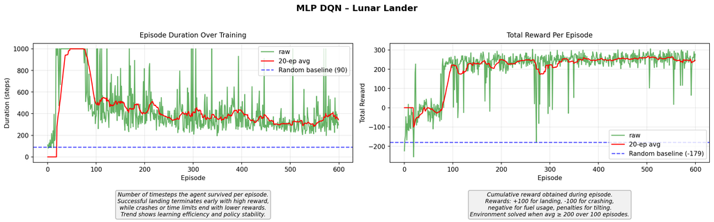

MLP DQN training

### Discussion

1. **Reward plateau around 250.** The agent learns to land successfully, but the reward does not improve much beyond 250. This either suggests the agent has reached the best possible reward given the current environment, or that it reaches a suboptimal policy that is good enough to land but not perfect. However, since the task is difficult, achieving a high reward around 250 is already a very promising result.
2. **Shortened episode duration.** For me, the shortened duration is unexpected, as I thought the agent would take more time to learn to land. But on second thought, it makes sense that the agent learns to land more quickly as it is hard to control the lander in a long episode, and also the reward structure encourages landing sooner.

## Extra Credit 2: DQN with CNN for car racing

Car racing is a much more complex environment, and training a DQN agent with convolutional layers to learn from pixels is significantly more challenging.

We created a DQN agent with convolutional layers to process the pixel input from the environment.

### Experimental Setup

**Preprocessing:** Each frame is converted to grayscale, cropped to remove the bottom status bar, and resized to $84 × 84$. Four consecutive frames are stacked to form a $(4, 84, 84)$ input tensor, giving the network temporal information about motion and velocity.

**Network architecture:** CNN-based DQN: A convolutional neural network with three convolutional layers followed by two fully connected layers: - Conv layers: Conv2d($4 → 32$, $8 × 8$, stride 4) $→$ ReLU $→$ Conv2d($32 → 64$, $4 × 4$, stride 2) $→$ ReLU $→$ Conv2d($64 → 64$, $3 × 3$, stride 1) $→$ ReLU - FC layers: Linear($3136 → 512$) $→$ ReLU $→$ Linear($512 → 5$)

**Hyperparameters:** - Batch size: 128 - Discount factor *γ* = 0.99 - Epsilon: $1.0 → 0.05$ (exponential decay over 50,000 steps) - Learning rate: 1 × 10<sup>−4</sup> (AdamW with AMSGrad) - Target network: soft update with *τ* = 0.005 every 4 steps - Replay memory: 50,000 transitions - Loss: Smooth L1 (Huber) loss - Gradient clipping: max value 100 - Optimization frequency: every 4 environment steps - Training episodes: 500 (GPU) / 30 (CPU) - cuDNN benchmark mode enabled for CNN acceleration